# SOC 325 Lab 5 - Analyzing Watch Data

Soc 325: Quantified-Self

Kim Nguyen

2023-02-10

# Preamble before starting the labs

You’ll download all R and RMarkdown files of the lab files for this class as `.zip` files from github as before. We will use library `googlesheets4` to access data for this lab. This will allow us to limit the data access to just UW or just this class as needed.

# Pyschology of R, RStudio and Labs

Scripting is HARD. That is ok, many hard things are useful! This is very helpful if you want to work as a data scientist. You need to familiarize yourself with the practices of coding and building analysis scripts.

**Why**

- Your work has to be reproducible
- Your work has to be able to hand off to someone else
- You need to be able to do lots of different things

**You Don’t need to do everything from scratch!!**

- It is ok to borrow code, use [stack overflow](https://stackoverflow.com/), [google](https://google.com), etc.
- Use books like [R for Data Science](https://r4ds.had.co.nz/introduction.html).

**Strategies for working in RMarkdown**

- DO **NOT** code a bunch and then *knit* – This will almost assuradely not work and crash!
- Do make small changes and *knit*
  - If you have a part that takes a long time (e.g. reading in data) turn `cache=TRUE` on in the R Chunk. This will pre-load it and make it faster.

# Analysis of Sleep Watches

## Load Libraries Needed For this Lab

For library management we use use the library `pacman`. The key with pacman is it will install and load the packages if needed. This makes our life easier!

The first line of code is `if (!require("pacman")) install.packages("pacman")` to install pacman if needed.

The second line `pacman::p_load([PACKAGES HERE])` uses `pacman` to load and install all the packages for the lab.

```r
## Run this code, to manage packages and install as needed.
# Install pacman
if (!require("pacman")) install.packages("pacman")
# p_load function loads packages if installed, or install then loads otherwise
pacman::p_load(tidyverse,haven,lubridate,ggthemes,kableExtra,here,ggpubr,rstatix,Routliers,reshape2,Routliers,gt,ggforce,car,data.table,zoom,magrittr,zoo,infer)
```

# Analyzing data from sleep watches

This is the data from

- Dunster, Gideon P., Isabelle Hua, Alex Grahe, Jason G. Fleischer, Satchidananda Panda, Kenneth P. Wright Jr, Céline Vetter, Jennifer H. Doherty, and Horacio O. de la Iglesia. “Daytime light exposure is a strong predictor of seasonal variation in sleep and circadian timing of university students.” Journal of Pineal Research (2022): e12843

The article is part of our weekly reading and available [here](https://drive.google.com/file/d/1RM2rgl2n8cyv77_BdoQAbycW7TWAMCx4/view?usp=share_link). *I highly recommened reading it!*

We will look at daily and weekend/weekday variation:

## Violin Plots

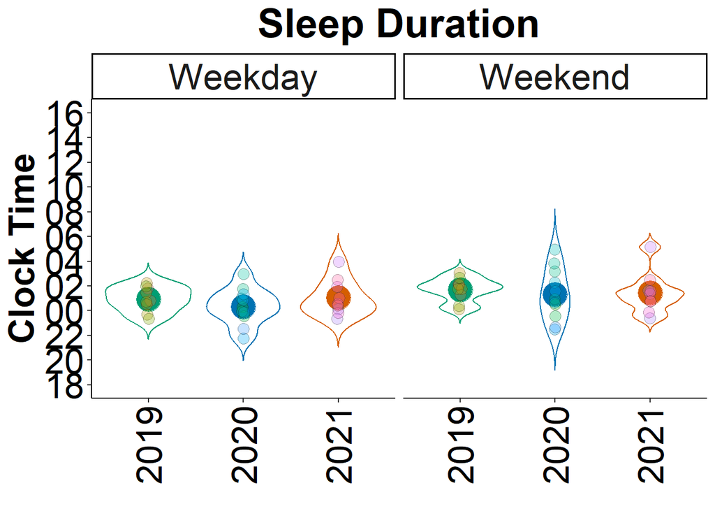

```r
df <- read.csv(here("data/lab_5/fitbit_data","IndividualSleepSummary.csv"))

#Set year and subject id as factors
df$year <- as.factor (df$year)
df$subjectid <- as.factor(df$subjectid)


####Violin plots (plots days separately) #########
df$onset_mean <- df$onset_mean - 24

#Clock time axis
yaxis <- c("18", "20", "22", "00", "02", "04", "06", "08", "10", "12", "14", "16")
yaxis <- str_pad(yaxis, 2, pad = "0")

#Plot
ggplot(df, aes(x = year, y = onset_mean)) + #Change y axis to whatever plotting (duration, onset, etc.)
  geom_violin(aes(color = year), trim = FALSE, show.legend = F,
              position = position_dodge(width = 0.3)) +
  stat_summary(aes(x = year, y = onset_mean, color = year), fun = "mean", geom = "point",
               size = 8, show.legend = F) + #Change y axis to whatever plotting (duration, onset, etc.)
  geom_sina (aes(fill = subjectid, group = year),
             show.legend = F, shape = 21,
             size = 3.5, alpha = 0.3, maxwidth = .05,
             position = position_dodge(width = 0.5)) +
  theme_classic () +
  theme(axis.text.x = element_text(size = 25, color = "black"),
        axis.text.y = element_text(size = 25, color = "black"),
        axis.title.y = element_text(size = 25, color = "black", face = "bold" ),
        legend.position = "none",
        strip.text = element_text(size = 25),
        plot.title = element_text(hjust = 0.5, size = 28, face = "bold")) +
  scale_color_manual (values = c("#009E73", "#0072B2", "#D55E00")) + #Change colors to match other plots
  labs(title = "Sleep Duration") +
  ylab ("Clock Time") + #y-axis label, change for duration (Hours)
  xlab ("") + #x-axis label
  theme(axis.text.x = element_text(angle = 90, vjust = 0.5, hjust=1))+
  #Set y- axis breaks below to be the same as in y-axis vector
  #will need to change for each parameter
  #clock time hour labels not needed for duaration plot
  scale_y_continuous(limits = c(-6, 16), breaks = seq (-6, 16, 2) , labels = yaxis) +
  facet_wrap(~day)
```

## Waveform Plots

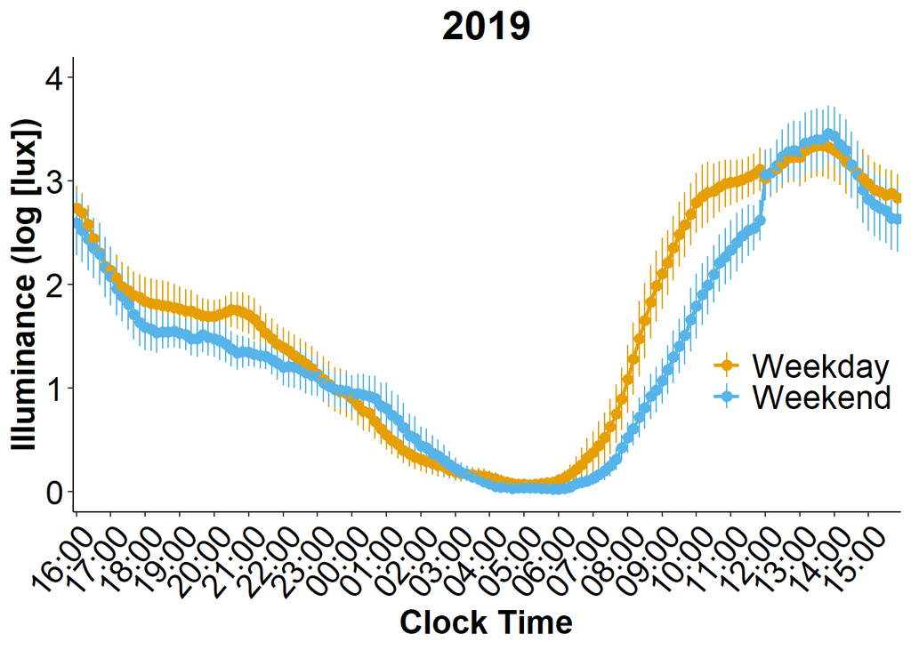

```r
filenames <- list.files(path=here("data/lab_5"),pattern = "\\.csv$") #Get .csv file names in directory
filenames<-filenames[-1]


#Combine data frame with all .csv files data
df<- lapply(here("data/lab_5",filenames), fread) %>%
  set_names(filenames) %>%
  rbindlist(idcol = "subjectid") #set column with identifier (subject id)

df$subjectid <- substr(df$subjectid,8,9) #make subjectid column into correct number

#Set subject ID as correct year
#If error "column 1 of item 22 does not match with column 1 of item 1"
#Go into file (in excel) named and format data the same as other files
df <- df %>% mutate(year =
                      case_when(subjectid <= 10 ~ "2019",
                                subjectid >=25 & subjectid <=49 ~ "2020",
                                subjectid >= 50 ~ "2021"))

#make subject, year, and day a factor
df$subjectid <- as.factor (df$subjectid)
df$day <- as.factor (df$day)
df$year <- as.factor(df$year)

#Make time into date/time format
df$Time <- as.POSIXct(df$Time, format="%H:%M:%S", tz = "America/Los_Angeles" )
df$Time <- strftime(df$Time, format="%H:%M")

#Alter data for running average #####

#Log of data (activity and light) + 1 - to not have N/A for zeros (for every individual file)
df$White.Light <- log(df$White.Light+1)

#rolling average for activity in light added to columns (grouped by subject)
df <- df %>%
  group_by(subjectid) %>%
  dplyr::mutate(meanactivity = rollmean(Activity, k = 6, fill = NA),
                loglight = rollmean(White.Light , k = 6, fill = NA))

#Mean for each time point seperated by subject (one point for each subject at each timepoint) ####
activity <- df %>%
  group_by(subjectid, Time, day, year) %>%
  dplyr::summarize(activity = mean(meanactivity, na.rm=TRUE)) #School day activity

light <- df %>%
  group_by(subjectid, Time, day, year) %>%
  dplyr::summarize(light = mean(loglight, na.rm=TRUE)) #weekend activity

#Mean for each timepoint seperated by day (one point per timepoint) ####
#Change time to a factor
activity$Time <- as.factor(activity$Time)
light$Time <- as.factor(light$Time)

#Change format of dataframe for saving file ####

activity_file <- activity %>%
  pivot_wider(names_from = subjectid, values_from = activity)

light_file <- light %>%
  pivot_wider(names_from = subjectid, values_from = light)


#Summarize activity data
activityplot <- activity %>%
  group_by(Time, year, day) %>%
  get_summary_stats(activity, type = "mean_se")

#summarize light data
lightplot <- light %>%
  group_by(Time, year, day) %>%
  get_summary_stats(light, type = "mean_se")

#Alter data for plotting #####
#Change Time column factor levels, so graph is plotted 16:00pm - 15:50pm
#Using row numnbers
activityplot$Time <- factor(activityplot$Time, levels(activityplot$Time)[c(97:144,1:96)])
lightplot$Time <- factor(lightplot$Time, levels(lightplot$Time)[c(97:144,1:96)])

level <- as.data.frame(levels (lightplot$Time)) #check that levels are correct

#Make waveform plot for DAY comparisons (School day v. weekend) ####
#Create wave forms
lightplot %>% #set correct data (light or activity)
  filter(year == "2019") %>% #filter for year
  ggplot(aes(x = Time, y = mean, group = day)) +
  geom_line(aes(color = day), lwd = 1) + #Add line
  geom_pointrange(aes(ymin=mean-se, ymax=mean+se, color = day), size = 0.5) +
  theme_classic() +
  xlab("Clock Time") +
  ylab("Illuminance (log [lux])") + #Axis title set for illuminance or activity
  ylim (0,4) + #y axis scale
  theme(axis.text.x = element_text(angle = 50, hjust = 1),
        legend.title = element_blank(), legend.position=c(.88, .3), #remove legend title & adjust position on graph
        legend.text=element_text(size=18), #legend text size
        axis.text=element_text(size=18, color = "black"),
        axis.title=element_text(size=18,face="bold", color = "black"),
        #legend.position="none",
        strip.text = element_text(size = 18),
        plot.title = element_text(hjust = 0.5, size = 22, face = "bold")) +
  scale_color_manual(values=c("#E69F00", "#56B4E9")) + #colors for School day vs weekend
  labs (title = "2019") +
  scale_x_discrete(breaks = levels(activityplot$Time)[c(T, rep(F, 5))]) #X axis
```

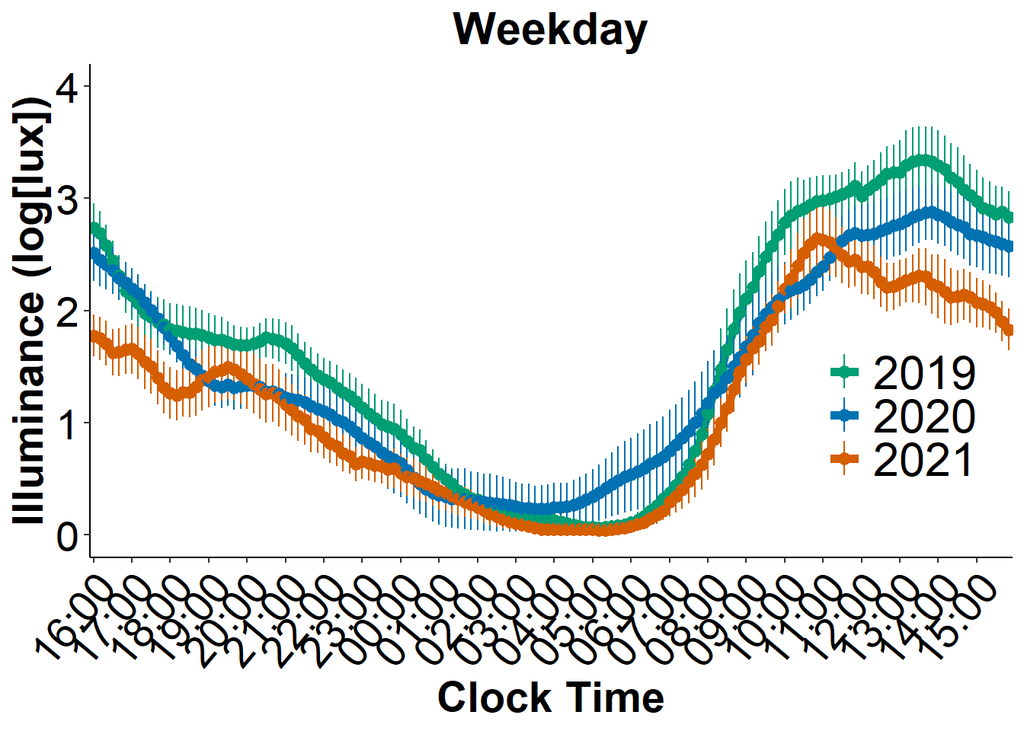

```r
#Make waveform plot for year comparisons (2019 v. 2020 v. 2021) ####
lightplot %>% #set correct data (light or activity)
  filter(day == "Weekday") %>% #filter for day (school day or weekend)
  ggplot(aes(x = Time, y = mean, group = year)) +
  geom_line(aes(color = year), lwd = 2) + #Add line
  geom_pointrange(aes(ymin=mean-se, ymax=mean+se, color = year), size = 0.5) +
  theme_classic() +
  scale_x_discrete(breaks = levels(lightplot$Time)[c(T, rep(F, 5))]) + #X axis
  xlab("Clock Time") +
  ylab("Illuminance (log[lux])") + #Axis set for illuminance or activity
  ylim (0,4) +
  labs (title = "Weekday") +
  theme(axis.text.x = element_text(angle = 50, hjust = 1),
        legend.title = element_blank(), legend.position=c(.88, .3), #remove legend title & adjust position on graph
        legend.text=element_text(size=23), #legend text size
        axis.text=element_text(size=21, color = "black"),
        axis.title=element_text(size=21,face="bold", color = "black"),
        plot.title = element_text(hjust = 0.5, size = 22, face = "bold"),
        #legend.position = "none"
        ) +
  scale_colour_manual(labels=c("2019", "2020", "2021"),
                      values=c("#009E73", "#0072B2", "#D55E00")) #color for years
```

# Assignment

For this lab we are going to analyze sleep data from a Fitbit tracker from Kaggle - [data](https://www.kaggle.com/datasets/riinuanslan/sleep-data-from-fitbit-tracker).

We can load this data directly,

```r
November_sleep<- read_csv(here("data/lab_5/fitbit_data","November Sleep Data - Sheet1.csv"))%>%na.omit()
December_sleep<- read_csv(here("data/lab_5/fitbit_data","December Sleep data - Sheet1.csv"))%>%na.omit()
January_sleep<- read_csv(here("data/lab_5/fitbit_data","January sleep data - Sheet1.csv"))%>%na.omit()
February_sleep<- read_csv(here("data/lab_5/fitbit_data","February sleep data - Sheet1 (1).csv"))%>%na.omit()
March_sleep<- read_csv(here("data/lab_5/fitbit_data","March sleep data - Sheet1.csv"))%>%na.omit()
April_sleep<- read_csv(here("data/lab_5/fitbit_data","April sleep data - Sheet1.csv"))%>%na.omit()
```

### Example analysis

Let’s look at November

**Step 1**

Clean data

```r
## Clean up the data
nov_clean<-November_sleep%>%mutate(
    st = str_split(`SLEEP TIME`," - ",simplify=TRUE)[, 1],
    wt= str_split(`SLEEP TIME`," - ",simplify=TRUE)[, 2],
    sd=if_else(str_detect(st,"am"),as.Date(DATE,"%m/%d/%Y")+1,as.Date(DATE,"%m/%d/%Y")),
    sleep_time = as.POSIXct(paste(sd,
            st),
            format='%Y-%m-%d %I:%M %p'),
    wd=if_else(str_detect(wt,"am"),as.Date(DATE,"%m/%d/%Y")+1,as.Date(DATE,"%m/%d/%Y")),
    wake_time = as.POSIXct(paste(wd,
            wt),
            format='%Y-%m-%d %I:%M %p'),
    time_slept_min= difftime(wake_time,sleep_time,units="mins"),
    time_slept_hour= difftime(wake_time,sleep_time,units="hour")
)
```

**Step 1.5: Print out Data**

```r
nov_clean%>%kbl(digits = 2) %>%
  kable_styling()%>%
   kable_paper("hover", full_width = F)
```

| NOVEMBER | DATE | SLEEP SCORE | HOURS OF SLEEP | REM SLEEP | DEEP SLEEP | HEART RATE BELOW RESTING | SLEEP TIME | st | wt | sd | sleep_time | wd | wake_time | time_slept_min | time_slept_hour |
| --- | --- | --- | --- | --- | --- | --- | --- | --- | --- | --- | --- | --- | --- | --- | --- |
| Monday | 11/1/2021 | 88 | 08:06:00 | 20.00% | 13.00% | 84.00% | 10:41pm - 7:54am | 10:41pm | 7:54am | 2021-11-01 | 2021-11-01 22:41:00 | 2021-11-02 | 2021-11-02 07:54:00 | 553 mins | 9.22 hours |
| Tuesday | 11/2/2021 | 83 | 07:57:00 | 12.00% | 18.00% | 90.00% | 10:40pm - 7:55am | 10:40pm | 7:55am | 2021-11-02 | 2021-11-02 22:40:00 | 2021-11-03 | 2021-11-03 07:55:00 | 555 mins | 9.25 hours |
| Wednesday | 11/3/2021 | 81 | 07:06:00 | 13.00% | 22.00% | 93.00% | 11:03pm - 7:16am | 11:03pm | 7:16am | 2021-11-03 | 2021-11-03 23:03:00 | 2021-11-04 | 2021-11-04 07:16:00 | 493 mins | 8.22 hours |
| Thursday | 11/4/2021 | 86 | 07:04:00 | 19.00% | 17.00% | 97.00% | 10:55pm - 6:56am | 10:55pm | 6:56am | 2021-11-04 | 2021-11-04 22:55:00 | 2021-11-05 | 2021-11-05 06:56:00 | 481 mins | 8.02 hours |
| Friday | 11/5/2021 | 81 | 09:24:00 | 17.00% | 15.00% | 66.00% | 10:14pm - 9:01am | 10:14pm | 9:01am | 2021-11-05 | 2021-11-05 22:14:00 | 2021-11-06 | 2021-11-06 09:01:00 | 647 mins | 10.78 hours |
| Saturday | 11/6/2021 | 77 | 08:19:00 | 14.00% | 13.00% | 21.00% | 11:21 - 8:45am | 11:21 | 8:45am | 2021-11-06 | NA | 2021-11-07 | 2021-11-07 08:45:00 | NA mins | NA hours |
| Sunday | 11/7/2021 | 86 | 07:37:00 | 20.00% | 15.00% | 80.00% | 11:18pm - 6:57am | 11:18pm | 6:57am | 2021-11-07 | 2021-11-07 23:18:00 | 2021-11-08 | 2021-11-08 06:57:00 | 459 mins | 7.65 hours |
| Monday | 11/8/2021 | 81 | 06:46:00 | 16% | 17.00% | 89.00% | 11:50pm - 7:40am | 11:50pm | 7:40am | 2021-11-08 | 2021-11-08 23:50:00 | 2021-11-09 | 2021-11-09 07:40:00 | 470 mins | 7.83 hours |
| Tuesday | 11/9/2021 | 88 | 07:10:00 | 24.00% | 19.00% | 98.00% | 11:14pm - 7:16am | 11:14pm | 7:16am | 2021-11-09 | 2021-11-09 23:14:00 | 2021-11-10 | 2021-11-10 07:16:00 | 482 mins | 8.03 hours |
| Wednesday | 11/10/2021 | 84 | 07:16:00 | 21.00% | 17.00% | 96.00% | 11:16pm - 7:29am | 11:16pm | 7:29am | 2021-11-10 | 2021-11-10 23:16:00 | 2021-11-11 | 2021-11-11 07:29:00 | 493 mins | 8.22 hours |
| Thursday | 11/11/2021 | 85 | 06:52:00 | 19.00% | 21.00% | 97.00% | 10:47pm - 6:32am | 10:47pm | 6:32am | 2021-11-11 | 2021-11-11 22:47:00 | 2021-11-12 | 2021-11-12 06:32:00 | 465 mins | 7.75 hours |
| Friday | 11/12/2021 | 85 | 07:28:00 | 18.00% | 16.00% | 74.00% | 10:21pm - 6:47am | 10:21pm | 6:47am | 2021-11-12 | 2021-11-12 22:21:00 | 2021-11-13 | 2021-11-13 06:47:00 | 506 mins | 8.43 hours |
| Saturday | 11/13/2021 | 74 | 06:06:00 | 16.00% | 21.00% | 43.00% | 11:34pm - 6:51am | 11:34pm | 6:51am | 2021-11-13 | 2021-11-13 23:34:00 | 2021-11-14 | 2021-11-14 06:51:00 | 437 mins | 7.28 hours |
| Sunday | 11/14/2021 | 88 | 06:59:00 | 23.00% | 22.00% | 91.00% | 10:54pm - 6:48am | 10:54pm | 6:48am | 2021-11-14 | 2021-11-14 22:54:00 | 2021-11-15 | 2021-11-15 06:48:00 | 474 mins | 7.90 hours |
| Monday | 11/15/2021 | 87 | 07:19:00 | 21.00% | 22.00% | 96.00% | 10:45pm - 6:57am | 10:45pm | 6:57am | 2021-11-15 | 2021-11-15 22:45:00 | 2021-11-16 | 2021-11-16 06:57:00 | 492 mins | 8.20 hours |
| Tuesday | 11/16/2021 | 80 | 07:22:00 | 17.00% | 11.00% | 55.00% | 11-38pm - 8:23am | 11-38pm | 8:23am | 2021-11-16 | NA | 2021-11-17 | 2021-11-17 08:23:00 | NA mins | NA hours |
| Wednesday | 11/17/2021 | 78 | 06:57:00 | 15.00% | 14.00% | 67.00% | 11:50pm - 7:50am | 11:50pm | 7:50am | 2021-11-17 | 2021-11-17 23:50:00 | 2021-11-18 | 2021-11-18 07:50:00 | 480 mins | 8.00 hours |
| Thursday | 11/18/2021 | 87 | 07:14:00 | 24.00% | 19.00% | 98.00% | 10:42pm - 6:51am | 10:42pm | 6:51am | 2021-11-18 | 2021-11-18 22:42:00 | 2021-11-19 | 2021-11-19 06:51:00 | 489 mins | 8.15 hours |
| Friday | 11/19/2021 | 83 | 06:50:00 | 20.00% | 20.00% | 75.00% | 10:49pm - 6:37am | 10:49pm | 6:37am | 2021-11-19 | 2021-11-19 22:49:00 | 2021-11-20 | 2021-11-20 06:37:00 | 468 mins | 7.80 hours |
| Saturday | 11/20/2021 | 86 | 07:56:00 | 24.00% | 17.00% | 63.00% | 10:53pm - 7:59am | 10:53pm | 7:59am | 2021-11-20 | 2021-11-20 22:53:00 | 2021-11-21 | 2021-11-21 07:59:00 | 546 mins | 9.10 hours |
| Sunday | 11/21/2021 | 88 | 07:33:00 | 19.00% | 16.00% | 95.00% | 11:13pm - 8:07am | 11:13pm | 8:07am | 2021-11-21 | 2021-11-21 23:13:00 | 2021-11-22 | 2021-11-22 08:07:00 | 534 mins | 8.90 hours |
| Monday | 11/22/2021 | 87 | 08:21:00 | 14.00% | 19.00% | 94.00% | 10:12pm - 7:32am | 10:12pm | 7:32am | 2021-11-22 | 2021-11-22 22:12:00 | 2021-11-23 | 2021-11-23 07:32:00 | 560 mins | 9.33 hours |
| Tuesday | 11/23/2021 | 86 | 08:15:00 | 20.00% | 14.00% | 72.00% | 11:53pm - 9:15am | 11:53pm | 9:15am | 2021-11-23 | 2021-11-23 23:53:00 | 2021-11-24 | 2021-11-24 09:15:00 | 562 mins | 9.37 hours |
| Wednesday | 11/24/2021 | 77 | 06:26:00 | 18.00% | 13.00% | 55.00% | 11:36pm - 7:13am | 11:36pm | 7:13am | 2021-11-24 | 2021-11-24 23:36:00 | 2021-11-25 | 2021-11-25 07:13:00 | 457 mins | 7.62 hours |
| Thursday | 11/25/2021 | 81 | 06:51:00 | 20.00% | 17.00% | 51.00% | 12:50am - 8:27am | 12:50am | 8:27am | 2021-11-26 | 2021-11-26 00:50:00 | 2021-11-26 | 2021-11-26 08:27:00 | 457 mins | 7.62 hours |
| Friday | 11/26/2021 | 87 | 08:45:00 | 22.00% | 19.00% | 56.00% | 12:53am - 10:35am | 12:53am | 10:35am | 2021-11-27 | 2021-11-27 00:53:00 | 2021-11-27 | 2021-11-27 10:35:00 | 582 mins | 9.70 hours |
| Saturday | 11/27/2021 | 86 | 07:53:00 | 24.00% | 19.00% | 66.00% | 12:51am - 10:04am | 12:51am | 10:04am | 2021-11-28 | 2021-11-28 00:51:00 | 2021-11-28 | 2021-11-28 10:04:00 | 553 mins | 9.22 hours |
| Sunday | 11/28/2021 | 83 | 06:13:00 | 22.00% | 22.00% | 81.00% | 12:02am - 6:59am | 12:02am | 6:59am | 2021-11-29 | 2021-11-29 00:02:00 | 2021-11-29 | 2021-11-29 06:59:00 | 417 mins | 6.95 hours |
| Monday | 11/29/2021 | 89 | 07:44:00 | 18.00% | 21.00% | 81.00% | 11:00pm - 7:38am | 11:00pm | 7:38am | 2021-11-29 | 2021-11-29 23:00:00 | 2021-11-30 | 2021-11-30 07:38:00 | 518 mins | 8.63 hours |
| Tuesday | 11/30/2021 | 78 | 06:48:00 | 12.00% | 13.00% | 74.00% | 11:16pm - 7:06am | 11:16pm | 7:06am | 2021-11-30 | 2021-11-30 23:16:00 | 2021-12-01 | 2021-12-01 07:06:00 | 470 mins | 7.83 hours |

**Step 2: Plot data**

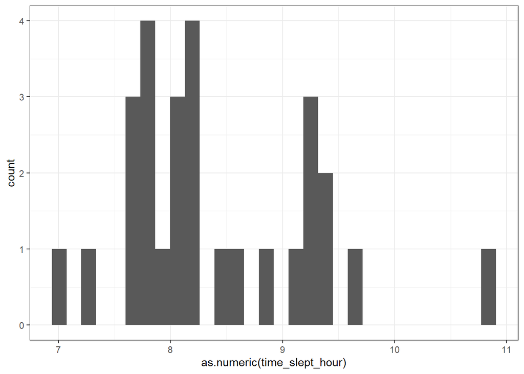

```r
## Check histogram of the data
nov_clean%>%
  ggplot(aes(x=as.numeric(time_slept_hour)))+
  geom_histogram()+
  theme_bw()
```

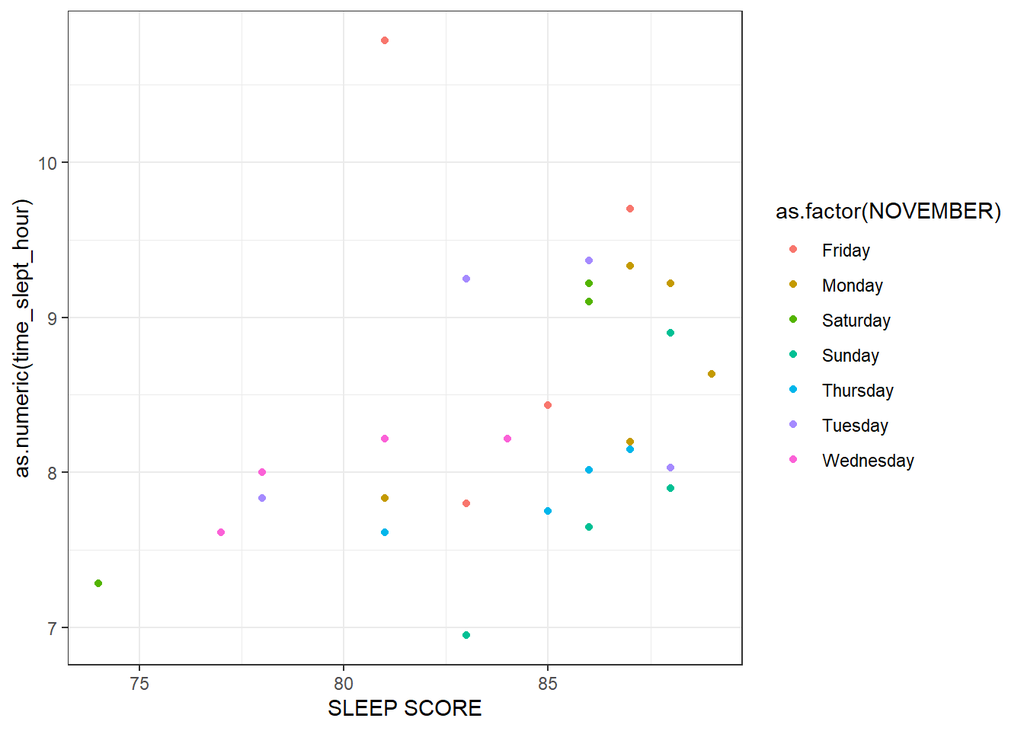

```r
## Check Scatter plot
nov_clean%>%
  ggplot(aes(y=as.numeric(time_slept_hour),x=`SLEEP SCORE`,color=as.factor(NOVEMBER)))+
  geom_point()+
  theme_bw()
```

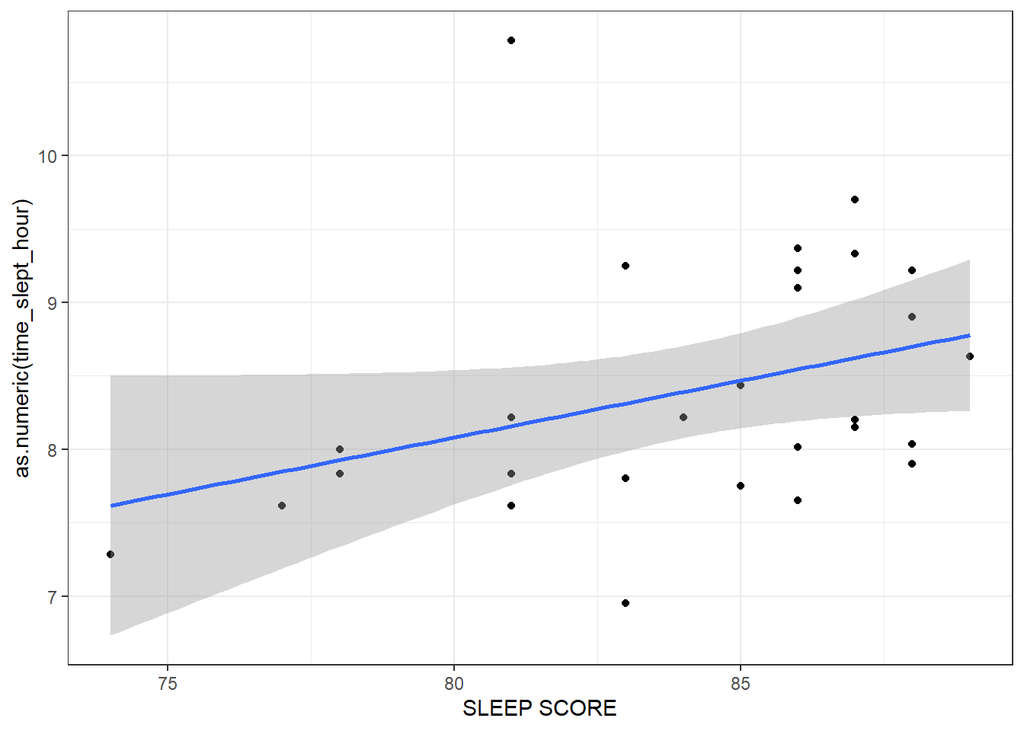

```r
## Check linear relationship between time slept and sleep scor
nov_clean%>%
  ggplot(aes(y=as.numeric(time_slept_hour),x=`SLEEP SCORE`))+
  geom_point()+
  geom_smooth(method="lm",formula='y ~ x')+
  theme_bw()
```

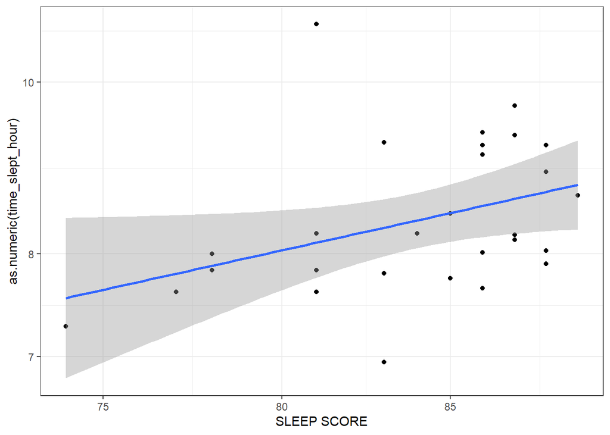

```r
## Check linear relationship between time slept and sleep score
## Log-Log plot

nov_clean%>%
  ggplot(aes(y=as.numeric(time_slept_hour),x=`SLEEP SCORE`))+
  geom_point()+
  scale_y_log10()+
  scale_x_log10()+
  geom_smooth(method="lm",formula='y ~ x')+
  theme_bw()
```

**Step 3: Explore the data**

```r
## Check that it makes sense

## Check Correlations between Sleep Score and Hourse Slept
nov_clean%>%summarise(cor=cor(`SLEEP SCORE`,as.numeric(time_slept_hour),use="na.or.complete"))
```

```
## # A tibble: 1 × 1
##     cor
##   <dbl>
## 1 0.354
```

```r
## Check the linear relationship between Day of the week and
#### sleep score
summary(lm(`SLEEP SCORE`~as.character(NOVEMBER)-1,data=nov_clean))
```

```
##
## Call:
## lm(formula = `SLEEP SCORE` ~ as.character(NOVEMBER) - 1, data = nov_clean)
##
## Residuals:
##    Min     1Q Median     3Q    Max
## -6.750 -3.000  0.600  2.125  5.250
##
## Coefficients:
##                                 Estimate Std. Error t value Pr(>|t|)
## as.character(NOVEMBER)Friday      84.000      1.834   45.80   <2e-16 ***
## as.character(NOVEMBER)Monday      86.400      1.640   52.67   <2e-16 ***
## as.character(NOVEMBER)Saturday    80.750      1.834   44.03   <2e-16 ***
## as.character(NOVEMBER)Sunday      86.250      1.834   47.03   <2e-16 ***
## as.character(NOVEMBER)Thursday    84.750      1.834   46.21   <2e-16 ***
## as.character(NOVEMBER)Tuesday     83.000      1.640   50.60   <2e-16 ***
## as.character(NOVEMBER)Wednesday   80.000      1.834   43.62   <2e-16 ***
## ---
## Signif. codes:  0 '***' 0.001 '**' 0.01 '*' 0.05 '.' 0.1 ' ' 1
##
## Residual standard error: 3.668 on 23 degrees of freedom
## Multiple R-squared:  0.9985, Adjusted R-squared:  0.9981
## F-statistic:  2231 on 7 and 23 DF,  p-value: < 2.2e-16
```

```r
## Check the linear relationship between Day of the week and
#### hours slept
summary(lm(as.numeric(time_slept_hour)~as.character(NOVEMBER)-1,data=nov_clean))
```

```
##
## Call:
## lm(formula = as.numeric(time_slept_hour) ~ as.character(NOVEMBER) -
##     1, data = nov_clean)
##
## Residuals:
##     Min      1Q  Median      3Q     Max
## -1.3792 -0.4794  0.0200  0.5683  1.6042
##
## Coefficients:
##                                 Estimate Std. Error t value Pr(>|t|)
## as.character(NOVEMBER)Friday      9.1792     0.4024   22.81 2.66e-16 ***
## as.character(NOVEMBER)Monday      8.6433     0.3599   24.02  < 2e-16 ***
## as.character(NOVEMBER)Saturday    8.5333     0.4646   18.36 2.05e-14 ***
## as.character(NOVEMBER)Sunday      7.8500     0.4024   19.51 6.17e-15 ***
## as.character(NOVEMBER)Thursday    7.8833     0.4024   19.59 5.67e-15 ***
## as.character(NOVEMBER)Tuesday     8.6208     0.4024   21.42 9.44e-16 ***
## as.character(NOVEMBER)Wednesday   8.0125     0.4024   19.91 4.10e-15 ***
## ---
## Signif. codes:  0 '***' 0.001 '**' 0.01 '*' 0.05 '.' 0.1 ' ' 1
##
## Residual standard error: 0.8048 on 21 degrees of freedom
##   (2 observations deleted due to missingness)
## Multiple R-squared:  0.9932, Adjusted R-squared:  0.9909
## F-statistic: 436.3 on 7 and 21 DF,  p-value: < 2.2e-16
```

## Question 1

In this question we will look at December and January Sleep

### Questions 1.1

Combine December and January data using the tidyverse method `OBJECT1 %>% bind_rows(OBJECT2)`. Save this object as `dec_jan`.

**Hint From Lecture**

```
## Rename DECEMBER/JANUARY Column
December_sleep<-December_sleep%>%rename(DayOfTheWeek=DECEMBER)
## Add Flag for month
December_sleep<-December_sleep%>%mutate(
  Month="December"
)

## Do same for Januyar
January_sleep<-January_sleep%>%rename(DayOfTheWeek=JANUARY)
January_sleep<-January_sleep%>%mutate(
  Month="January"
)

## Combine
dec_jan<-December_sleep%>%bind_rows(January_sleep)
```

YOUR SOLUTION HERE

```r
## Rename DECEMBER/JANUARY Column
December_sleep<-December_sleep%>%rename(DayOfTheWeek=DECEMBER)
## Add Flag for month
December_sleep<-December_sleep%>%mutate(
  Month="December"
)

## Do same for January
January_sleep<-January_sleep%>%rename(DayOfTheWeek=JANUARY)
January_sleep<-January_sleep%>%mutate(
  Month="January"
)

## Combine
dec_jan<-December_sleep%>%bind_rows(January_sleep)
```

END OF YOUR SOLUTION HERE

### Questions 1.2

Repeat the cleaning steps used in NOVEMBER

YOUR SOLUTION HERE

```r
November_sleep <- November_sleep %>%
  rename(DayOfTheWeek = NOVEMBER)

November_sleep <- November_sleep %>%
  mutate(Month = "November")

ndj <- dec_jan %>%
  bind_rows(November_sleep)
```

END OF YOUR SOLUTION HERE

### Questions 1.3

Print out out the `ndj` object using the `kbl()` function.

YOUR SOLUTION HERE

```r
ndj%>%kbl(digits = 2) %>%
  kable_styling()%>%
   kable_paper("hover", full_width = F)
```

| DayOfTheWeek | DATE | SLEEP SCORE | HOURS OF SLEEP | REM SLEEP | DEEP SLEEP | HEART RATE BELOW RESTING | SLEEP TIME | Month | HEART RATE UNDER RESTING |
| --- | --- | --- | --- | --- | --- | --- | --- | --- | --- |
| Wednesday | 12/01/2021 | 91 | 07:33:00 | 23.00% | 19.00% | 98.00% | 10:56pm - 7:20am | December | NA |
| Thursday | 12/02/2021 | 81 | 07:17:00 | 16.00% | 13.00% | 94.00% | 10:45pm - 6:58am | December | NA |
| Friday | 12/03/2021 | 80 | 07:17:00 | 15.00% | 17.00% | 78.00% | 10:51pm - 7:02am | December | NA |
| Saturday | 12/04/2021 | 85 | 08:23:00 | 20.00% | 15.00% | 58.00% | 9:53pm - 7:17am | December | NA |
| Sunday | 12/05/2021 | 82 | 07:19:00 | 20.00% | 12.00% | 79.00% | 11:54pm - 8:16am | December | NA |
| Monday | 12/06/2021 | 80 | 07:18:00 | 18.00% | 16.00% | 56.00% | 11:28pm - 7:47am | December | NA |
| Tuesday | 12/07/2021 | 89 | 08:02:00 | 21.00% | 11.00% | 94.00% | 10:09pm - 7:18am | December | NA |
| Wednesday | 12/08/2021 | 85 | 06:47:00 | 22.00% | 16.00% | 94.00% | 11:40pm - 7:33 | December | NA |
| Thursday | 12/09/2021 | 85 | 07:32:00 | 12.00% | 14.00% | 96.00% | 10:47pm - 7:27am | December | NA |
| Friday | 12/10/2021 | 87 | 07:45:00 | 20.00% | 13.00% | 75.00% | 10:27pm - 7:07am | December | NA |
| Saturday | 12/11/2021 | 78 | 07:57:00 | 13.00% | 10.00% | 45.00% | 11:44pm - 9:05am | December | NA |
| Sunday | 12/12/2021 | 85 | 06:47:00 | 24.00% | 17.00% | 74.00% | 12:21am - 8:18am | December | NA |
| Monday | 12/13/2021 | 87 | 08:33:00 | 21.00% | 15.00% | 83.00% | 10:13pm - 7:47am | December | NA |
| Tuesday | 12/14/2021 | 83 | 07:33:00 | 12.00% | 20.00% | 76.00% | 11:19pm - 7:54am | December | NA |
| Wednesday | 12/15/2021 | 79 | 07:08:00 | 26.00% | 19.00% | 31.00% | 11:00pm - 6:58am | December | NA |
| Thursday | 12/16/2021 | 74 | 06:34:00 | 16.00% | 23.00% | 0.00% | 12:38am - 8:18am | December | NA |
| Friday | 12/17/2021 | 84 | 07:18:00 | 21.00% | 16.00% | 79.00% | 11:54pm - 8:10am | December | NA |
| Saturday | 12/18/2021 | 87 | 08:14:00 | 16.00% | 18.00% | 99.00% | 10:44pm - 8:16am | December | NA |
| Sunday | 12/19/2021 | 83 | 07:08:00 | 29.00% | 17.00% | 65.00% | 11:57pm - 7:57am | December | NA |
| Monday | 12/20/2021 | 85 | 07:06:00 | 23.00% | 14.00% | 98.00% | 12:42am - 8:51am | December | NA |
| Tuesday | 12/21/2021 | 91 | 08:26:00 | 21.00% | 19.00% | 96.00% | 10:25pm - 8:01am | December | NA |
| Wednesday | 12/22/2021 | 88 | 07:29:00 | 22.00% | 16.00% | 90.00% | 11:01pm - 7:42am | December | NA |
| Thursday | 12/23/2021 | 89 | 08:37:00 | 20.00% | 19.00% | 95.00% | 11:24pm - 9:18am | December | NA |
| Friday | 12/24/2021 | 78 | 09:03:00 | 12.00% | 18.00% | 52.00% | 11:20pm - 9:56am | December | NA |
| Saturday | 12/25/2021 | 75 | 06:39:00 | 16.00% | 14.00% | 50.00% | 01:19am - 9:06am | December | NA |
| Sunday | 12/26/2021 | 91 | 07:51:00 | 21.00% | 27.00% | 83.00% | 12:14am - 9:08am | December | NA |
| Monday | 12/27/2021 | 83 | 07:06:00 | 20.00% | 16.00% | 90.00% | 12:00am - 8:09am | December | NA |
| Tuesday | 12/28/2021 | 85 | 06:57:00 | 20.00% | 18.00% | 99.00% | 11:16pm - 7:02 | December | NA |
| Wednesday | 12/29/2021 | 91 | 07:23:00 | 26.00% | 16.00% | 98.00% | 10:51pm - 7:09am | December | NA |
| Thursday | 12/30/2021 | 87 | 07:48:00 | 22.00% | 21.00% | 60.00% | 11:34pm - 8:18am | December | NA |

[output cut: 62 more lines]

END OF YOUR SOLUTION HERE

### Questions 1.4

Plot the `ndj_clean` object similar to example analysis on NOVEMBER.

YOUR SOLUTION HERE

```r
# Clean up data
ndj_clean<-ndj%>%mutate(
    st = str_split(`SLEEP TIME`," - ",simplify=TRUE)[, 1],
    wt= str_split(`SLEEP TIME`," - ",simplify=TRUE)[, 2],
    sd=if_else(str_detect(st,"am"),as.Date(DATE,"%m/%d/%Y")+1,as.Date(DATE,"%m/%d/%Y")),
    sleep_time = as.POSIXct(paste(sd,
            st),
            format='%Y-%m-%d %I:%M %p'),
    wd=if_else(str_detect(wt,"am"),as.Date(DATE,"%m/%d/%Y")+1,as.Date(DATE,"%m/%d/%Y")),
    wake_time = as.POSIXct(paste(wd,
            wt),
            format='%Y-%m-%d %I:%M %p'),
    time_slept_min= difftime(wake_time,sleep_time,units="mins"),
    time_slept_hour= difftime(wake_time,sleep_time,units="hour")
)
```

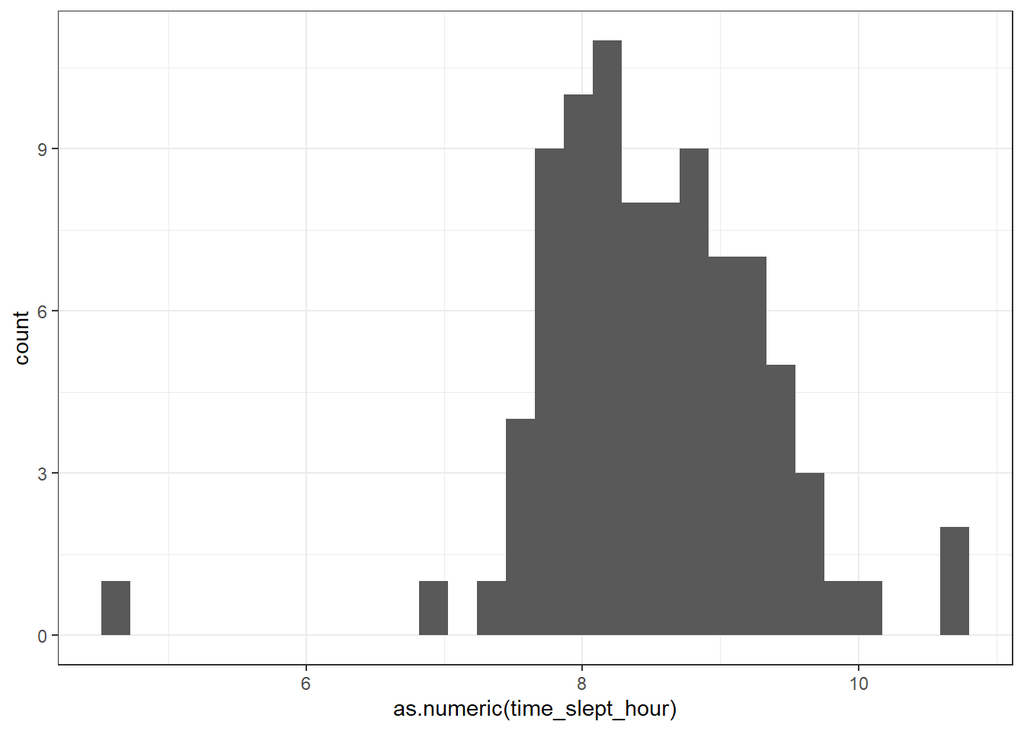

```r
## Check histogram of the data
ndj_clean%>%
  ggplot(aes(x=as.numeric(time_slept_hour)))+
  geom_histogram()+
  theme_bw()
```

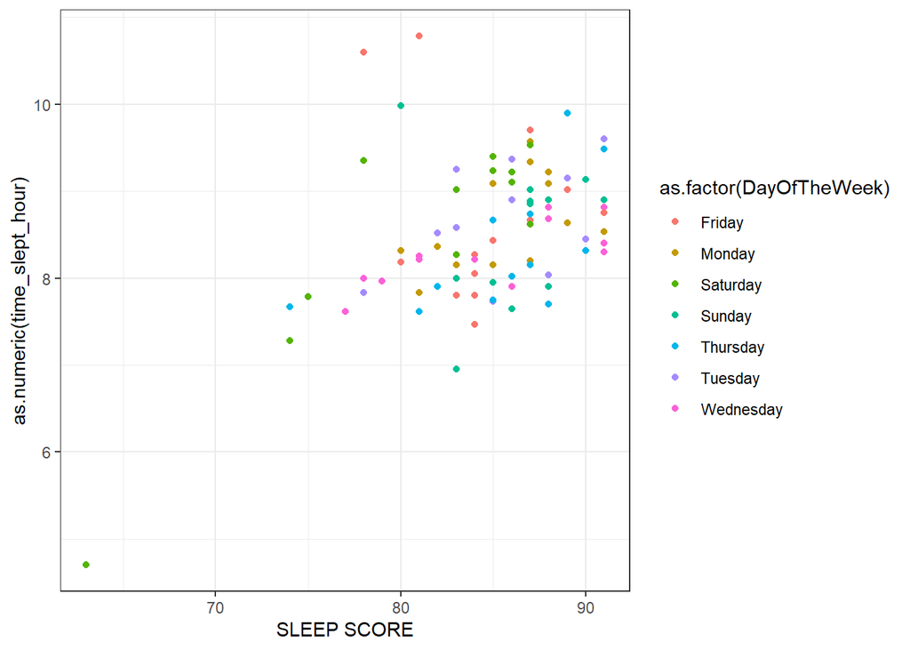

```r
## Check Scatter plot
ndj_clean%>%
  ggplot(aes(y=as.numeric(time_slept_hour),x=`SLEEP SCORE`,color=as.factor(DayOfTheWeek)))+
  geom_point()+
  theme_bw()
```

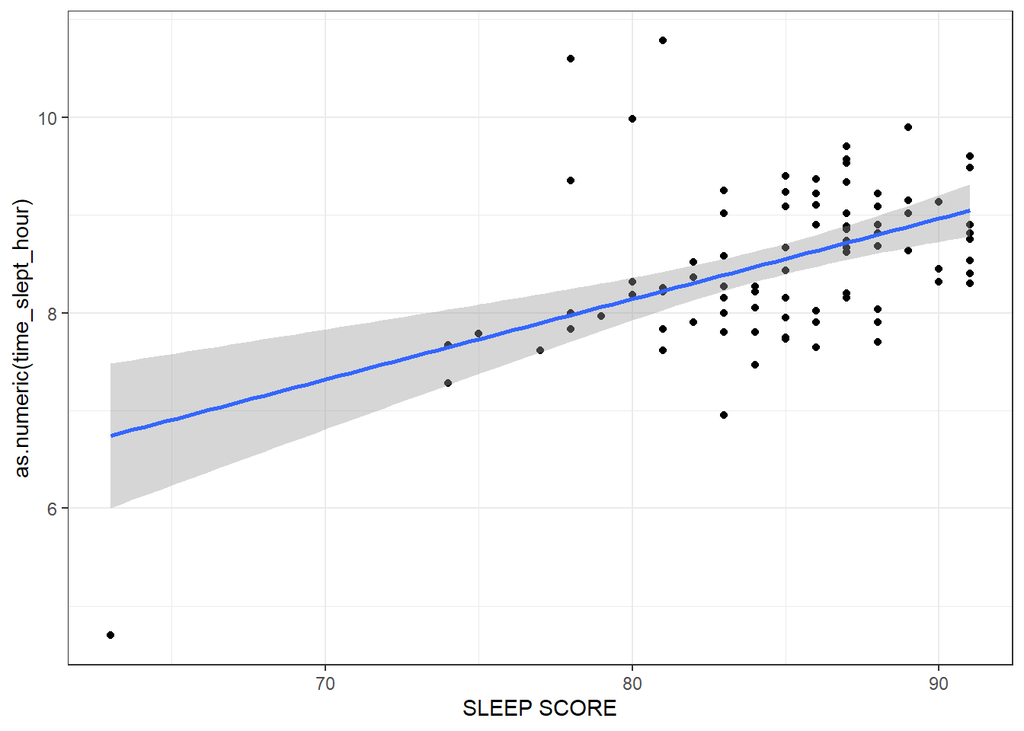

```r
## Check linear relationship between time slept and sleep scor
ndj_clean%>%
  ggplot(aes(y=as.numeric(time_slept_hour),x=`SLEEP SCORE`))+
  geom_point()+
  geom_smooth(method="lm",formula='y ~ x')+
  theme_bw()
```

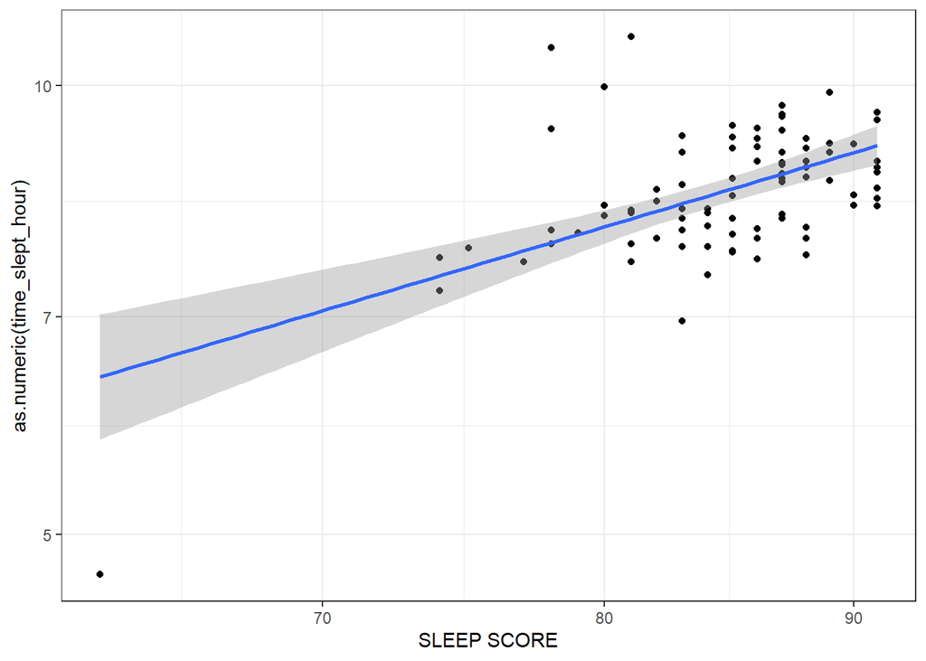

```r
## Check linear relationship between time slept and sleep score
## Log-Log plot

ndj_clean%>%
  ggplot(aes(y=as.numeric(time_slept_hour),x=`SLEEP SCORE`))+
  geom_point()+
  scale_y_log10()+
  scale_x_log10()+
  geom_smooth(method="lm",formula='y ~ x')+
  theme_bw()
```

END OF YOUR SOLUTION HERE

### Questions 1.5

Perform the exploratory analysis on `ndj_clean` object similar to example analysis on NOVEMBER.

YOUR SOLUTION HERE

```r
## Check Correlations between Sleep Score and Hours Slept
ndj_clean%>%summarise(cor=cor(`SLEEP SCORE`,as.numeric(time_slept_hour),use="na.or.complete"))
```

```
## # A tibble: 1 × 1
##     cor
##   <dbl>
## 1 0.467
```

```r
## Check the linear relationship between Day of the week and
#### sleep score
summary(lm(`SLEEP SCORE`~as.character(DayOfTheWeek)-1,data=ndj_clean))
```

```
##
## Call:
## lm(formula = `SLEEP SCORE` ~ as.character(DayOfTheWeek) - 1,
##     data = ndj_clean)
##
## Residuals:
##     Min      1Q  Median      3Q     Max
## -17.692  -3.077   0.500   3.038   6.615
##
## Coefficients:
##                                     Estimate Std. Error t value Pr(>|t|)
## as.character(DayOfTheWeek)Friday      84.385      1.259   67.03   <2e-16 ***
## as.character(DayOfTheWeek)Monday      85.429      1.213   70.42   <2e-16 ***
## as.character(DayOfTheWeek)Saturday    80.692      1.259   64.10   <2e-16 ***
## as.character(DayOfTheWeek)Sunday      85.923      1.259   68.25   <2e-16 ***
## as.character(DayOfTheWeek)Thursday    85.077      1.259   67.58   <2e-16 ***
## as.character(DayOfTheWeek)Tuesday     85.077      1.259   67.58   <2e-16 ***
## as.character(DayOfTheWeek)Wednesday   84.615      1.259   67.22   <2e-16 ***
## ---
## Signif. codes:  0 '***' 0.001 '**' 0.01 '*' 0.05 '.' 0.1 ' ' 1
##
## Residual standard error: 4.539 on 85 degrees of freedom
## Multiple R-squared:  0.9973, Adjusted R-squared:  0.9971
## F-statistic:  4553 on 7 and 85 DF,  p-value: < 2.2e-16
```

```r
## Check the linear relationship between Day of the week and
#### hours slept
summary(lm(as.numeric(time_slept_hour)~as.character(DayOfTheWeek)-1,data=ndj_clean))
```

```
##
## Call:
## lm(formula = as.numeric(time_slept_hour) ~ as.character(DayOfTheWeek) -
##     1, data = ndj_clean)
##
## Residuals:
##     Min      1Q  Median      3Q     Max
## -3.7583 -0.5274 -0.0486  0.5233  2.0513
##
## Coefficients:
##                                     Estimate Std. Error t value Pr(>|t|)
## as.character(DayOfTheWeek)Friday      8.7321     0.2321   37.62   <2e-16 ***
## as.character(DayOfTheWeek)Monday      8.6774     0.2237   38.79   <2e-16 ***
## as.character(DayOfTheWeek)Saturday    8.4583     0.2416   35.01   <2e-16 ***
## as.character(DayOfTheWeek)Sunday      8.4987     0.2321   36.61   <2e-16 ***
## as.character(DayOfTheWeek)Thursday    8.3167     0.2321   35.83   <2e-16 ***
## as.character(DayOfTheWeek)Tuesday     8.6742     0.2523   34.37   <2e-16 ***
## as.character(DayOfTheWeek)Wednesday   8.2653     0.2416   34.21   <2e-16 ***
## ---
## Signif. codes:  0 '***' 0.001 '**' 0.01 '*' 0.05 '.' 0.1 ' ' 1
##
## Residual standard error: 0.8369 on 81 degrees of freedom
##   (4 observations deleted due to missingness)
## Multiple R-squared:  0.9912, Adjusted R-squared:  0.9904
## F-statistic:  1303 on 7 and 81 DF,  p-value: < 2.2e-16
```

END OF YOUR SOLUTION HERE

### Questions 1.6

Interpret your plots and analysis here:

YOUR SOLUTION HERE

Graphs:

- Bar Graph: There seems to be a bell-shape that forms with few outliers, which means that the average time that people sleep is around 8 hours
- Scatter and Linear Relationship Graph: It looks as though there’s no real pattern between the different days of the week. However, there is a clear upward trend the higher the sleep score.

Analysis:

- I’m not exactly sure what the residuals and cor are supposed to stand for
- Seems as though Saturday has the least in terms of sleep score, having an average of 80.69 while every other day is around the 85 level
- Wednesday logs the least average hours of sleep at 8.2 hours, while the most (Friday) goes for 8.7 hours

It looks like that, despite the stereotypes of students and their sleep schedules, a lot people actually manage to get a good 8 hours of sleep!

END OF YOUR SOLUTION HERE